# Case_study_1_Cyclistic

Miracle

2023-03-22

# Merging monthly reports into quarterly files

### STEP-1 We start with loading required tools and setting working directory

```r
library(tidyverse)  #helps wrangle data
```

```r
library(lubridate)  #helps wrangle date attributes
library(ggplot2)  #helps visualize data
getwd() #displays your working directory
```

```
## [1] "C:/my filess/Data-Analysis/Case_study_1_Cyclistic_bike-share"
```

### STEP-2 Then we upload necessary documents from directory and name them

```r
march22_table<-read.csv("202203-divvy-tripdata.csv")
april22_table<-read.csv("202204-divvy-tripdata.csv")
may22_table<-read.csv("202205-divvy-tripdata.csv")
```

### STEP-3 Before merging them, we have to check if the names of columns are consistent

While the names don’t have to be in the same order, they DO need to match perfectly before we can use a command to join them into one file

```r
colnames(march22_table)
```

```
##  [1] "ride_id"            "rideable_type"      "started_at"
##  [4] "ended_at"           "start_station_name" "start_station_id"
##  [7] "end_station_name"   "end_station_id"     "start_lat"
## [10] "start_lng"          "end_lat"            "end_lng"
## [13] "member_casual"
```

```r
colnames(april22_table)
```

```
##  [1] "ride_id"            "rideable_type"      "started_at"
##  [4] "ended_at"           "start_station_name" "start_station_id"
##  [7] "end_station_name"   "end_station_id"     "start_lat"
## [10] "start_lng"          "end_lat"            "end_lng"
## [13] "member_casual"
```

```r
colnames(may22_table)
```

```
##  [1] "ride_id"            "rideable_type"      "started_at"
##  [4] "ended_at"           "start_station_name" "start_station_id"
##  [7] "end_station_name"   "end_station_id"     "start_lat"
## [10] "start_lng"          "end_lat"            "end_lng"
## [13] "member_casual"
```

### STEP-4 Now we change ride_id and rideable_type columns to character so they can stack correctly

```r
march22_table<- mutate(march22_table, ride_id=as.character(ride_id),
                     rideable_type=as.character(rideable_type))
april22_table<- mutate(april22_table, ride_id=as.character(ride_id),
                     rideable_type=as.character(rideable_type))
may22_table<- mutate(may22_table, ride_id=as.character(ride_id),
                   rideable_type=as.character(rideable_type))
```

### STEP-5 Then we recheck the dataframes

```r
str(march22_table)
```

```
## 'data.frame':    284042 obs. of  13 variables:
##  $ ride_id           : chr  "47EC0A7F82E65D52" "8494861979B0F477" "EFE527AF80B66109" "9F446FD9DEE3F389" ...
##  $ rideable_type     : chr  "classic_bike" "electric_bike" "classic_bike" "classic_bike" ...
##  $ started_at        : chr  "2022-03-21 13:45:01" "2022-03-16 09:37:16" "2022-03-23 19:52:02" "2022-03-01 19:12:26" ...
##  $ ended_at          : chr  "2022-03-21 13:51:18" "2022-03-16 09:43:34" "2022-03-23 19:54:48" "2022-03-01 19:22:14" ...
##  $ start_station_name: chr  "Wabash Ave & Wacker Pl" "Michigan Ave & Oak St" "Broadway & Berwyn Ave" "Wabash Ave & Wacker Pl" ...
##  $ start_station_id  : chr  "TA1307000131" "13042" "13109" "TA1307000131" ...
##  $ end_station_name  : chr  "Kingsbury St & Kinzie St" "Orleans St & Chestnut St (NEXT Apts)" "Broadway & Ridge Ave" "Franklin St & Jackson Blvd" ...
##  $ end_station_id    : chr  "KA1503000043" "620" "15578" "TA1305000025" ...
##  $ start_lat         : num  41.9 41.9 42 41.9 41.9 ...
##  $ start_lng         : num  -87.6 -87.6 -87.7 -87.6 -87.6 ...
##  $ end_lat           : num  41.9 41.9 42 41.9 41.9 ...
##  $ end_lng           : num  -87.6 -87.6 -87.7 -87.6 -87.7 ...
##  $ member_casual     : chr  "member" "member" "member" "member" ...
```

```r
str(april22_table)
```

```
## 'data.frame':    371249 obs. of  13 variables:
##  $ ride_id           : chr  "3564070EEFD12711" "0B820C7FCF22F489" "89EEEE32293F07FF" "84D4751AEB31888D" ...
##  $ rideable_type     : chr  "electric_bike" "classic_bike" "classic_bike" "classic_bike" ...
##  $ started_at        : chr  "2022-04-06 17:42:48" "2022-04-24 19:23:07" "2022-04-20 19:29:08" "2022-04-22 21:14:06" ...
##  $ ended_at          : chr  "2022-04-06 17:54:36" "2022-04-24 19:43:17" "2022-04-20 19:35:16" "2022-04-22 21:23:29" ...
##  $ start_station_name: chr  "Paulina St & Howard St" "Wentworth Ave & Cermak Rd" "Halsted St & Polk St" "Wentworth Ave & Cermak Rd" ...
##  $ start_station_id  : chr  "515" "13075" "TA1307000121" "13075" ...
##  $ end_station_name  : chr  "University Library (NU)" "Green St & Madison St" "Green St & Madison St" "Delano Ct & Roosevelt Rd" ...
##  $ end_station_id    : chr  "605" "TA1307000120" "TA1307000120" "KA1706005007" ...
##  $ start_lat         : num  42 41.9 41.9 41.9 41.9 ...
##  $ start_lng         : num  -87.7 -87.6 -87.6 -87.6 -87.6 ...
##  $ end_lat           : num  42.1 41.9 41.9 41.9 41.9 ...
##  $ end_lng           : num  -87.7 -87.6 -87.6 -87.6 -87.6 ...
##  $ member_casual     : chr  "member" "member" "member" "casual" ...
```

```r
str(may22_table)
```

```
## 'data.frame':    634858 obs. of  13 variables:
##  $ ride_id           : chr  "EC2DE40644C6B0F4" "1C31AD03897EE385" "1542FBEC830415CF" "6FF59852924528F8" ...
##  $ rideable_type     : chr  "classic_bike" "classic_bike" "classic_bike" "classic_bike" ...
##  $ started_at        : chr  "2022-05-23 23:06:58" "2022-05-11 08:53:28" "2022-05-26 18:36:28" "2022-05-10 07:30:07" ...
##  $ ended_at          : chr  "2022-05-23 23:40:19" "2022-05-11 09:31:22" "2022-05-26 18:58:18" "2022-05-10 07:38:49" ...
##  $ start_station_name: chr  "Wabash Ave & Grand Ave" "DuSable Lake Shore Dr & Monroe St" "Clinton St & Madison St" "Clinton St & Madison St" ...
##  $ start_station_id  : chr  "TA1307000117" "13300" "TA1305000032" "TA1305000032" ...
##  $ end_station_name  : chr  "Halsted St & Roscoe St" "Field Blvd & South Water St" "Wood St & Milwaukee Ave" "Clark St & Randolph St" ...
##  $ end_station_id    : chr  "TA1309000025" "15534" "13221" "TA1305000030" ...
##  $ start_lat         : num  41.9 41.9 41.9 41.9 41.9 ...
##  $ start_lng         : num  -87.6 -87.6 -87.6 -87.6 -87.6 ...
##  $ end_lat           : num  41.9 41.9 41.9 41.9 41.9 ...
##  $ end_lng           : num  -87.6 -87.6 -87.7 -87.6 -87.7 ...
##  $ member_casual     : chr  "member" "member" "member" "member" ...
```

### STEP-6 Finally, we start to merge individual monthly files into quarterly reports

```r
spring_2022<- bind_rows(march22_table,april22_table,may22_table)
```

### STEP-6 Now it is time to inspect the created table

```r
colnames(spring_2022)   # list of column names
```

```
##  [1] "ride_id"            "rideable_type"      "started_at"
##  [4] "ended_at"           "start_station_name" "start_station_id"
##  [7] "end_station_name"   "end_station_id"     "start_lat"
## [10] "start_lng"          "end_lat"            "end_lng"
## [13] "member_casual"
```

```r
head(spring_2022)  # to see first 6 rows
```

```
##            ride_id rideable_type          started_at            ended_at
## 1 47EC0A7F82E65D52  classic_bike 2022-03-21 13:45:01 2022-03-21 13:51:18
## 2 8494861979B0F477 electric_bike 2022-03-16 09:37:16 2022-03-16 09:43:34
## 3 EFE527AF80B66109  classic_bike 2022-03-23 19:52:02 2022-03-23 19:54:48
## 4 9F446FD9DEE3F389  classic_bike 2022-03-01 19:12:26 2022-03-01 19:22:14
## 5 431128AD9AFFEDC0  classic_bike 2022-03-21 18:37:01 2022-03-21 19:19:11
## 6 9AA8A13AF7A85325  classic_bike 2022-03-07 17:10:22 2022-03-07 17:15:04
##                   start_station_name start_station_id
## 1             Wabash Ave & Wacker Pl     TA1307000131
## 2              Michigan Ave & Oak St            13042
## 3              Broadway & Berwyn Ave            13109
## 4             Wabash Ave & Wacker Pl     TA1307000131
## 5 DuSable Lake Shore Dr & North Blvd           LF-005
## 6          Bissell St & Armitage Ave            13059
##                       end_station_name end_station_id start_lat start_lng
## 1             Kingsbury St & Kinzie St   KA1503000043  41.88688 -87.62603
## 2 Orleans St & Chestnut St (NEXT Apts)            620  41.90100 -87.62375
## 3                 Broadway & Ridge Ave          15578  41.97835 -87.65975
## 4           Franklin St & Jackson Blvd   TA1305000025  41.88688 -87.62603
## 5             Loomis St & Jackson Blvd          13206  41.91172 -87.62680
## 6         Southport Ave & Clybourn Ave   TA1309000030  41.91802 -87.65218
##    end_lat   end_lng member_casual
## 1 41.88918 -87.63851        member
## 2 41.89820 -87.63754        member
## 3 41.98404 -87.66027        member
## 4 41.87771 -87.63532        member
## 5 41.87794 -87.66201        member
## 6 41.92077 -87.66371        member
```

```r
tail(spring_2022)  # to see last 6 rows
```

```
##                  ride_id rideable_type          started_at            ended_at
## 1290144 284843EC9F8C5663  classic_bike 2022-05-30 18:34:44 2022-05-31 19:34:35
## 1290145 8891BA0053ECEC4F electric_bike 2022-05-27 22:00:02 2022-05-27 22:07:01
## 1290146 47D8B5FBCADECFC1 electric_bike 2022-05-15 16:05:39 2022-05-15 16:44:12
## 1290147 AA8D16CF38B40703 electric_bike 2022-05-21 10:10:13 2022-05-21 10:26:09
## 1290148 897EBFD44F329E0A electric_bike 2022-05-12 07:53:58 2022-05-12 08:01:18
## 1290149 AAC23AB89E8A7733 electric_bike 2022-05-11 21:14:28 2022-05-11 21:18:16
##                       start_station_name start_station_id end_station_name
## 1290144            Ashland Ave & Lake St            13073
## 1290145            Clark St & Newport St              632
## 1290146            Clark St & Newport St              632
## 1290147 Francisco Ave & Bloomingdale Ave              429
## 1290148 Francisco Ave & Bloomingdale Ave              429
## 1290149            Clark St & Newport St              632
##         end_station_id start_lat start_lng end_lat end_lng member_casual
## 1290144                 41.88592 -87.66717      NA      NA        casual
## 1290145                 41.94456 -87.65483   41.92  -87.65        member
## 1290146                 41.94448 -87.65476   41.92  -87.76        member
## 1290147                 41.91000 -87.70000   41.92  -87.66        casual
## 1290148                 41.91000 -87.70000   41.90  -87.69        member
## 1290149                 41.94457 -87.65480   41.94  -87.65        member
```

```r
nrow(spring_2022)  # how many rows in the table
```

```
## [1] 1290149
```

```r
dim(spring_2022)   # Dimensions of the data
```

```
## [1] 1290149      13
```

```r
summary(spring_2022)  # Statistical summary of the data, mainly numeric
```

```
##    ride_id          rideable_type       started_at          ended_at
##  Length:1290149     Length:1290149     Length:1290149     Length:1290149
##  Class :character   Class :character   Class :character   Class :character
##  Mode  :character   Mode  :character   Mode  :character   Mode  :character
##
##
##
##
##  start_station_name start_station_id   end_station_name   end_station_id
##  Length:1290149     Length:1290149     Length:1290149     Length:1290149
##  Class :character   Class :character   Class :character   Class :character
##  Mode  :character   Mode  :character   Mode  :character   Mode  :character
##
##
##
##
##    start_lat       start_lng         end_lat         end_lng
##  Min.   :41.65   Min.   :-87.84   Min.   :41.63   Min.   :-88.14
##  1st Qu.:41.88   1st Qu.:-87.66   1st Qu.:41.88   1st Qu.:-87.66
##  Median :41.90   Median :-87.64   Median :41.90   Median :-87.64
##  Mean   :41.90   Mean   :-87.65   Mean   :41.90   Mean   :-87.65
##  3rd Qu.:41.93   3rd Qu.:-87.63   3rd Qu.:41.93   3rd Qu.:-87.63
##  Max.   :42.07   Max.   :-87.52   Max.   :42.11   Max.   :-87.51
##                                   NA's   :1305    NA's   :1305
##  member_casual
##  Length:1290149
##  Class :character
##  Mode  :character
##
##
##
##
```

### (SUMMER) Then we will repeat given steps for other monthly reports too Uploading files

```r
june22_table<-read.csv("202206-divvy-tripdata.csv")
july22_table<-read.csv("202207-divvy-tripdata.csv")
august22_table<-read.csv("202208-divvy-tripdata.csv")
```

Check columns if they match perfectly

```r
colnames(june22_table)
```

```
##  [1] "ride_id"            "rideable_type"      "started_at"
##  [4] "ended_at"           "start_station_name" "start_station_id"
##  [7] "end_station_name"   "end_station_id"     "start_lat"
## [10] "start_lng"          "end_lat"            "end_lng"
## [13] "member_casual"
```

```r
colnames(july22_table)
```

```
##  [1] "ride_id"            "rideable_type"      "started_at"
##  [4] "ended_at"           "start_station_name" "start_station_id"
##  [7] "end_station_name"   "end_station_id"     "start_lat"
## [10] "start_lng"          "end_lat"            "end_lng"
## [13] "member_casual"
```

```r
colnames(august22_table)
```

```
##  [1] "ride_id"            "rideable_type"      "started_at"
##  [4] "ended_at"           "start_station_name" "start_station_id"
##  [7] "end_station_name"   "end_station_id"     "start_lat"
## [10] "start_lng"          "end_lat"            "end_lng"
## [13] "member_casual"
```

Change to character of ride_id and rideable_type columns

```r
june22_table<- mutate(june22_table, ride_id=as.character(ride_id),
                     rideable_type=as.character(rideable_type))
july22_table<- mutate(july22_table, ride_id=as.character(ride_id),
                     rideable_type=as.character(rideable_type))
august22_table<- mutate(august22_table, ride_id=as.character(ride_id),
                   rideable_type=as.character(rideable_type))
```

Checking dataframe for errors

```r
str(june22_table)
```

```
## 'data.frame':    769204 obs. of  13 variables:
##  $ ride_id           : chr  "600CFD130D0FD2A4" "F5E6B5C1682C6464" "B6EB6D27BAD771D2" "C9C320375DE1D5C6" ...
##  $ rideable_type     : chr  "electric_bike" "electric_bike" "electric_bike" "electric_bike" ...
##  $ started_at        : chr  "2022-06-30 17:27:53" "2022-06-30 18:39:52" "2022-06-30 11:49:25" "2022-06-30 11:15:25" ...
##  $ ended_at          : chr  "2022-06-30 17:35:15" "2022-06-30 18:47:28" "2022-06-30 12:02:54" "2022-06-30 11:19:43" ...
##  $ start_station_name: chr  "" "" "" "" ...
##  $ start_station_id  : chr  "" "" "" "" ...
##  $ end_station_name  : chr  "" "" "" "" ...
##  $ end_station_id    : chr  "" "" "" "" ...
##  $ start_lat         : num  41.9 41.9 41.9 41.8 41.9 ...
##  $ start_lng         : num  -87.6 -87.6 -87.7 -87.7 -87.6 ...
##  $ end_lat           : num  41.9 41.9 41.9 41.8 41.9 ...
##  $ end_lng           : num  -87.6 -87.6 -87.6 -87.7 -87.6 ...
##  $ member_casual     : chr  "casual" "casual" "casual" "casual" ...
```

```r
str(july22_table)
```

```
## 'data.frame':    823488 obs. of  13 variables:
##  $ ride_id           : chr  "954144C2F67B1932" "292E027607D218B6" "57765852588AD6E0" "B5B6BE44314590E6" ...
##  $ rideable_type     : chr  "classic_bike" "classic_bike" "classic_bike" "classic_bike" ...
##  $ started_at        : chr  "2022-07-05 08:12:47" "2022-07-26 12:53:38" "2022-07-03 13:58:49" "2022-07-31 17:44:21" ...
##  $ ended_at          : chr  "2022-07-05 08:24:32" "2022-07-26 12:55:31" "2022-07-03 14:06:32" "2022-07-31 18:42:50" ...
##  $ start_station_name: chr  "Ashland Ave & Blackhawk St" "Buckingham Fountain (Temp)" "Buckingham Fountain (Temp)" "Buckingham Fountain (Temp)" ...
##  $ start_station_id  : chr  "13224" "15541" "15541" "15541" ...
##  $ end_station_name  : chr  "Kingsbury St & Kinzie St" "Michigan Ave & 8th St" "Michigan Ave & 8th St" "Woodlawn Ave & 55th St" ...
##  $ end_station_id    : chr  "KA1503000043" "623" "623" "TA1307000164" ...
##  $ start_lat         : num  41.9 41.9 41.9 41.9 41.9 ...
##  $ start_lng         : num  -87.7 -87.6 -87.6 -87.6 -87.6 ...
##  $ end_lat           : num  41.9 41.9 41.9 41.8 41.9 ...
##  $ end_lng           : num  -87.6 -87.6 -87.6 -87.6 -87.7 ...
##  $ member_casual     : chr  "member" "casual" "casual" "casual" ...
```

```r
str(august22_table)
```

```
## 'data.frame':    785932 obs. of  13 variables:
##  $ ride_id           : chr  "550CF7EFEAE0C618" "DAD198F405F9C5F5" "E6F2BC47B65CB7FD" "F597830181C2E13C" ...
##  $ rideable_type     : chr  "electric_bike" "electric_bike" "electric_bike" "electric_bike" ...
##  $ started_at        : chr  "2022-08-07 21:34:15" "2022-08-08 14:39:21" "2022-08-08 15:29:50" "2022-08-08 02:43:50" ...
##  $ ended_at          : chr  "2022-08-07 21:41:46" "2022-08-08 14:53:23" "2022-08-08 15:40:34" "2022-08-08 02:58:53" ...
##  $ start_station_name: chr  "" "" "" "" ...
##  $ start_station_id  : chr  "" "" "" "" ...
##  $ end_station_name  : chr  "" "" "" "" ...
##  $ end_station_id    : chr  "" "" "" "" ...
##  $ start_lat         : num  41.9 41.9 42 41.9 41.9 ...
##  $ start_lng         : num  -87.7 -87.6 -87.7 -87.7 -87.7 ...
##  $ end_lat           : num  41.9 41.9 42 42 41.8 ...
##  $ end_lng           : num  -87.7 -87.6 -87.7 -87.7 -87.7 ...
##  $ member_casual     : chr  "casual" "casual" "casual" "casual" ...
```

### Last step: Merging

```r
summer_2022<-bind_rows(june22_table,july22_table,august22_table)
```

Inspect the result

```r
colnames(summer_2022)   # list of column names
```

```
##  [1] "ride_id"            "rideable_type"      "started_at"
##  [4] "ended_at"           "start_station_name" "start_station_id"
##  [7] "end_station_name"   "end_station_id"     "start_lat"
## [10] "start_lng"          "end_lat"            "end_lng"
## [13] "member_casual"
```

```r
head(summer_2022)  # to see first 6 rows
```

```
##            ride_id rideable_type          started_at            ended_at
## 1 600CFD130D0FD2A4 electric_bike 2022-06-30 17:27:53 2022-06-30 17:35:15
## 2 F5E6B5C1682C6464 electric_bike 2022-06-30 18:39:52 2022-06-30 18:47:28
## 3 B6EB6D27BAD771D2 electric_bike 2022-06-30 11:49:25 2022-06-30 12:02:54
## 4 C9C320375DE1D5C6 electric_bike 2022-06-30 11:15:25 2022-06-30 11:19:43
## 5 56C055851023BE98 electric_bike 2022-06-29 23:36:50 2022-06-29 23:45:17
## 6 B664188E8163D045 electric_bike 2022-06-30 16:42:10 2022-06-30 16:58:22
##   start_station_name start_station_id end_station_name end_station_id start_lat
## 1                                                                         41.89
## 2                                                                         41.91
## 3                                                                         41.91
## 4                                                                         41.80
## 5                                                                         41.91
## 6                                                                         42.03
##   start_lng end_lat end_lng member_casual
## 1    -87.62   41.91  -87.62        casual
## 2    -87.62   41.93  -87.63        casual
## 3    -87.65   41.89  -87.61        casual
## 4    -87.66   41.80  -87.65        casual
## 5    -87.63   41.93  -87.64        casual
## 6    -87.71   42.06  -87.73        casual
```

```r
tail(summer_2022)  # to see last 6 rows
```

```
##                  ride_id rideable_type          started_at            ended_at
## 2378619 3A50755D869397FB electric_bike 2022-08-09 06:41:21 2022-08-09 06:45:22
## 2378620 EC17BE8AB1D73C88 electric_bike 2022-08-12 08:28:26 2022-08-12 08:42:26
## 2378621 57BAC0EA3A067A83 electric_bike 2022-08-22 12:30:19 2022-08-22 12:36:32
## 2378622 9B97FAE30276C299 electric_bike 2022-08-09 07:43:31 2022-08-09 07:50:50
## 2378623 2B4A9BA1E9AA9B51 electric_bike 2022-08-24 14:31:58 2022-08-24 14:40:32
## 2378624 7F0D048AC7C3B81A electric_bike 2022-08-24 09:45:04 2022-08-24 09:45:19
##                   start_station_name start_station_id end_station_name
## 2378619 Ashland Ave & Wellington Ave            13269
## 2378620    Paulina St & Montrose Ave     TA1309000021
## 2378621     California Ave & 21st St            13096
## 2378622 Clinton St & Washington Blvd           WL-012
## 2378623 Ashland Ave & Wellington Ave            13269
## 2378624       Clark St & Lincoln Ave            13179
##         end_station_id start_lat start_lng end_lat end_lng member_casual
## 2378619                 41.93610 -87.66984   41.94  -87.68        member
## 2378620                 41.96156 -87.67143   41.94  -87.64        member
## 2378621                 41.85375 -87.69581   41.84  -87.69        member
## 2378622                 41.88340 -87.64122   41.89  -87.66        member
## 2378623                 41.93608 -87.66990   41.93  -87.64        member
## 2378624                 41.91578 -87.63468   41.92  -87.63        member
```

```r
nrow(summer_2022)  # how many rows in the table
```

```
## [1] 2378624
```

```r
dim(summer_2022)   # Dimensions of the data
```

```
## [1] 2378624      13
```

```r
summary(summer_2022)  # Statistical summary of the data, mainly numeric
```

```
##    ride_id          rideable_type       started_at          ended_at
##  Length:2378624     Length:2378624     Length:2378624     Length:2378624
##  Class :character   Class :character   Class :character   Class :character
##  Mode  :character   Mode  :character   Mode  :character   Mode  :character
##
##
##
##
##  start_station_name start_station_id   end_station_name   end_station_id
##  Length:2378624     Length:2378624     Length:2378624     Length:2378624
##  Class :character   Class :character   Class :character   Class :character
##  Mode  :character   Mode  :character   Mode  :character   Mode  :character
##
##
##
##
##    start_lat       start_lng         end_lat         end_lng
##  Min.   :41.64   Min.   :-87.84   Min.   :41.60   Min.   :-88.05
##  1st Qu.:41.88   1st Qu.:-87.66   1st Qu.:41.88   1st Qu.:-87.66
##  Median :41.90   Median :-87.64   Median :41.90   Median :-87.64
##  Mean   :41.91   Mean   :-87.65   Mean   :41.91   Mean   :-87.65
##  3rd Qu.:41.93   3rd Qu.:-87.63   3rd Qu.:41.93   3rd Qu.:-87.63
##  Max.   :42.07   Max.   :-87.52   Max.   :42.37   Max.   :-87.50
##                                   NA's   :2845    NA's   :2845
##  member_casual
##  Length:2378624
##  Class :character
##  Mode  :character
##
##
##
##
```

# Fall quarter

```r
september22_table<-read.csv("202209-divvy-tripdata.csv")
october22_table<-read.csv("202210-divvy-tripdata.csv")
november22_table<-read.csv("202211-divvy-tripdata.csv")
```

Check the column names

```r
colnames(september22_table)
```

```
##  [1] "ride_id"            "rideable_type"      "started_at"
##  [4] "ended_at"           "start_station_name" "start_station_id"
##  [7] "end_station_name"   "end_station_id"     "start_lat"
## [10] "start_lng"          "end_lat"            "end_lng"
## [13] "member_casual"
```

```r
colnames(october22_table)
```

```
##  [1] "ride_id"            "rideable_type"      "started_at"
##  [4] "ended_at"           "start_station_name" "start_station_id"
##  [7] "end_station_name"   "end_station_id"     "start_lat"
## [10] "start_lng"          "end_lat"            "end_lng"
## [13] "member_casual"
```

```r
colnames(november22_table)
```

```
##  [1] "ride_id"            "rideable_type"      "started_at"
##  [4] "ended_at"           "start_station_name" "start_station_id"
##  [7] "end_station_name"   "end_station_id"     "start_lat"
## [10] "start_lng"          "end_lat"            "end_lng"
## [13] "member_casual"
```

Change to character

```r
september22_table<- mutate(september22_table, ride_id=as.character(ride_id),
                     rideable_type=as.character(rideable_type))
october22_table<- mutate(october22_table, ride_id=as.character(ride_id),
                     rideable_type=as.character(rideable_type))
november22_table<- mutate(november22_table, ride_id=as.character(ride_id),
                   rideable_type=as.character(rideable_type))
```

Check the dataframes

```r
str(september22_table)
```

```
## 'data.frame':    701339 obs. of  13 variables:
##  $ ride_id           : chr  "5156990AC19CA285" "E12D4A16BF51C274" "A02B53CD7DB72DD7" "C82E05FEE872DF11" ...
##  $ rideable_type     : chr  "electric_bike" "electric_bike" "electric_bike" "electric_bike" ...
##  $ started_at        : chr  "2022-09-01 08:36:22" "2022-09-01 17:11:29" "2022-09-01 17:15:50" "2022-09-01 09:00:28" ...
##  $ ended_at          : chr  "2022-09-01 08:39:05" "2022-09-01 17:14:45" "2022-09-01 17:16:12" "2022-09-01 09:10:32" ...
##  $ start_station_name: chr  "" "" "" "" ...
##  $ start_station_id  : chr  "" "" "" "" ...
##  $ end_station_name  : chr  "California Ave & Milwaukee Ave" "" "" "" ...
##  $ end_station_id    : chr  "13084" "" "" "" ...
##  $ start_lat         : num  41.9 41.9 41.9 41.9 41.9 ...
##  $ start_lng         : num  -87.7 -87.6 -87.6 -87.7 -87.7 ...
##  $ end_lat           : num  41.9 41.9 41.9 41.9 41.9 ...
##  $ end_lng           : num  -87.7 -87.6 -87.6 -87.7 -87.7 ...
##  $ member_casual     : chr  "casual" "casual" "casual" "casual" ...
```

```r
str(october22_table)
```

```
## 'data.frame':    558685 obs. of  13 variables:
##  $ ride_id           : chr  "A50255C1E17942AB" "DB692A70BD2DD4E3" "3C02727AAF60F873" "47E653FDC2D99236" ...
##  $ rideable_type     : chr  "classic_bike" "electric_bike" "electric_bike" "electric_bike" ...
##  $ started_at        : chr  "2022-10-14 17:13:30" "2022-10-01 16:29:26" "2022-10-19 18:55:40" "2022-10-31 07:52:36" ...
##  $ ended_at          : chr  "2022-10-14 17:19:39" "2022-10-01 16:49:06" "2022-10-19 19:03:30" "2022-10-31 07:58:49" ...
##  $ start_station_name: chr  "Noble St & Milwaukee Ave" "Damen Ave & Charleston St" "Hoyne Ave & Balmoral Ave" "Rush St & Cedar St" ...
##  $ start_station_id  : chr  "13290" "13288" "655" "KA1504000133" ...
##  $ end_station_name  : chr  "Larrabee St & Division St" "Damen Ave & Cullerton St" "Western Ave & Leland Ave" "Orleans St & Chestnut St (NEXT Apts)" ...
##  $ end_station_id    : chr  "KA1504000079" "13089" "TA1307000140" "620" ...
##  $ start_lat         : num  41.9 41.9 42 41.9 41.9 ...
##  $ start_lng         : num  -87.7 -87.7 -87.7 -87.6 -87.6 ...
##  $ end_lat           : num  41.9 41.9 42 41.9 41.9 ...
##  $ end_lng           : num  -87.6 -87.7 -87.7 -87.6 -87.6 ...
##  $ member_casual     : chr  "member" "casual" "member" "member" ...
```

```r
str(november22_table)
```

```
## 'data.frame':    337735 obs. of  13 variables:
##  $ ride_id           : chr  "BCC66FC6FAB27CC7" "772AB67E902C180F" "585EAD07FDEC0152" "91C4E7ED3C262FF9" ...
##  $ rideable_type     : chr  "electric_bike" "classic_bike" "classic_bike" "classic_bike" ...
##  $ started_at        : chr  "2022-11-10 06:21:55" "2022-11-04 07:31:55" "2022-11-21 17:20:29" "2022-11-25 17:29:34" ...
##  $ ended_at          : chr  "2022-11-10 06:31:27" "2022-11-04 07:46:25" "2022-11-21 17:34:36" "2022-11-25 17:45:15" ...
##  $ start_station_name: chr  "Canal St & Adams St" "Canal St & Adams St" "Indiana Ave & Roosevelt Rd" "Indiana Ave & Roosevelt Rd" ...
##  $ start_station_id  : chr  "13011" "13011" "SL-005" "SL-005" ...
##  $ end_station_name  : chr  "St. Clair St & Erie St" "St. Clair St & Erie St" "St. Clair St & Erie St" "St. Clair St & Erie St" ...
##  $ end_station_id    : chr  "13016" "13016" "13016" "13016" ...
##  $ start_lat         : num  41.9 41.9 41.9 41.9 41.9 ...
##  $ start_lng         : num  -87.6 -87.6 -87.6 -87.6 -87.6 ...
##  $ end_lat           : num  41.9 41.9 41.9 41.9 41.9 ...
##  $ end_lng           : num  -87.6 -87.6 -87.6 -87.6 -87.6 ...
##  $ member_casual     : chr  "member" "member" "member" "member" ...
```

Merging

```r
fall_2022<-bind_rows(september22_table,october22_table,november22_table)
```

Inspecting the results

```r
colnames(fall_2022)   # list of column names
```

```
##  [1] "ride_id"            "rideable_type"      "started_at"
##  [4] "ended_at"           "start_station_name" "start_station_id"
##  [7] "end_station_name"   "end_station_id"     "start_lat"
## [10] "start_lng"          "end_lat"            "end_lng"
## [13] "member_casual"
```

```r
head(fall_2022)  # to see first 6 rows
```

```
##            ride_id rideable_type          started_at            ended_at
## 1 5156990AC19CA285 electric_bike 2022-09-01 08:36:22 2022-09-01 08:39:05
## 2 E12D4A16BF51C274 electric_bike 2022-09-01 17:11:29 2022-09-01 17:14:45
## 3 A02B53CD7DB72DD7 electric_bike 2022-09-01 17:15:50 2022-09-01 17:16:12
## 4 C82E05FEE872DF11 electric_bike 2022-09-01 09:00:28 2022-09-01 09:10:32
## 5 4DEEB4550A266AE1 electric_bike 2022-09-01 07:30:11 2022-09-01 07:32:36
## 6 B1721F8C7C3AC6BF electric_bike 2022-09-01 12:04:25 2022-09-01 12:21:08
##   start_station_name start_station_id               end_station_name
## 1                                     California Ave & Milwaukee Ave
## 2
## 3
## 4
## 5
## 6
##   end_station_id start_lat start_lng  end_lat   end_lng member_casual
## 1          13084     41.93    -87.69 41.92269 -87.69715        casual
## 2                    41.87    -87.62 41.87000 -87.62000        casual
## 3                    41.87    -87.62 41.87000 -87.62000        casual
## 4                    41.93    -87.69 41.94000 -87.67000        casual
## 5                    41.92    -87.73 41.92000 -87.73000        casual
## 6                    41.89    -87.65 41.92000 -87.67000        casual
```

```r
tail(fall_2022)  # to see last 6 rows
```

```
##                  ride_id rideable_type          started_at            ended_at
## 1597754 E4F708DDC80A274C electric_bike 2022-11-20 17:38:28 2022-11-20 17:41:01
## 1597755 C349E243A9BAA6F7 electric_bike 2022-11-25 11:19:52 2022-11-25 11:31:50
## 1597756 B0B4E85DA43A9194  classic_bike 2022-11-22 16:57:53 2022-11-22 17:31:29
## 1597757 8D148DD47B59530B  classic_bike 2022-11-06 13:04:05 2022-11-06 13:13:33
## 1597758 0D1170BA18FD33D1  classic_bike 2022-11-06 09:41:29 2022-11-06 15:17:17
## 1597759 09B20DC75B5EA1E0 electric_bike 2022-11-26 11:59:28 2022-11-26 12:31:04
##                    start_station_name start_station_id
## 1597754        Wabash Ave & Grand Ave     TA1307000117
## 1597755        Wabash Ave & Grand Ave     TA1307000117
## 1597756    Franklin St & Jackson Blvd     TA1305000025
## 1597757 Michigan Ave & Ida B Wells Dr     TA1305000010
## 1597758          Halsted St & 18th St            13099
## 1597759 Michigan Ave & Ida B Wells Dr     TA1305000010
##                       end_station_name end_station_id start_lat start_lng
## 1597754                                                41.89151 -87.62669
## 1597755                                                41.89184 -87.62681
## 1597756 Sheffield Ave & Wrightwood Ave   TA1309000023  41.87771 -87.63532
## 1597757                 Shedd Aquarium          15544  41.87624 -87.62443
## 1597758                 Shedd Aquarium          15544  41.85751 -87.64599
## 1597759                 Shedd Aquarium          15544  41.87627 -87.62458
##          end_lat   end_lng member_casual
## 1597754 41.89000 -87.62000        member
## 1597755 41.89000 -87.62000        member
## 1597756 41.92871 -87.65383        casual
## 1597757 41.86723 -87.61536        casual
## 1597758 41.86723 -87.61536        casual
## 1597759 41.86723 -87.61536        casual
```

```r
nrow(fall_2022)  # how many rows in the table
```

```
## [1] 1597759
```

```r
dim(fall_2022)   # Dimensions of the data
```

```
## [1] 1597759      13
```

```r
summary(fall_2022)  # Statistical summary of the data, mainly numeric
```

```
##    ride_id          rideable_type       started_at          ended_at
##  Length:1597759     Length:1597759     Length:1597759     Length:1597759
##  Class :character   Class :character   Class :character   Class :character
##  Mode  :character   Mode  :character   Mode  :character   Mode  :character
##
##
##
##
##  start_station_name start_station_id   end_station_name   end_station_id
##  Length:1597759     Length:1597759     Length:1597759     Length:1597759
##  Class :character   Class :character   Class :character   Class :character
##  Mode  :character   Mode  :character   Mode  :character   Mode  :character
##
##
##
##
##    start_lat       start_lng         end_lat         end_lng
##  Min.   :41.64   Min.   :-87.84   Min.   : 0.00   Min.   :-87.92
##  1st Qu.:41.88   1st Qu.:-87.66   1st Qu.:41.88   1st Qu.:-87.66
##  Median :41.90   Median :-87.65   Median :41.90   Median :-87.65
##  Mean   :41.90   Mean   :-87.65   Mean   :41.90   Mean   :-87.65
##  3rd Qu.:41.93   3rd Qu.:-87.63   3rd Qu.:41.93   3rd Qu.:-87.63
##  Max.   :42.07   Max.   :-87.52   Max.   :42.15   Max.   :  0.00
##                                   NA's   :1417    NA's   :1417
##  member_casual
##  Length:1597759
##  Class :character
##  Mode  :character
##
##
##
##
```

# Winter quarter

Upload the docs

```r
december22_table<-read.csv("202212-divvy-tripdata.csv")
january23_table<-read.csv("202301-divvy-tripdata.csv")
february23_table<-read.csv("202302-divvy-tripdata.csv")
```

Check the column names if they are the same

```r
colnames(december22_table)
```

```
##  [1] "ride_id"            "rideable_type"      "started_at"
##  [4] "ended_at"           "start_station_name" "start_station_id"
##  [7] "end_station_name"   "end_station_id"     "start_lat"
## [10] "start_lng"          "end_lat"            "end_lng"
## [13] "member_casual"
```

```r
colnames(january23_table)
```

```
##  [1] "ride_id"            "rideable_type"      "started_at"
##  [4] "ended_at"           "start_station_name" "start_station_id"
##  [7] "end_station_name"   "end_station_id"     "start_lat"
## [10] "start_lng"          "end_lat"            "end_lng"
## [13] "member_casual"
```

```r
colnames(february23_table)
```

```
##  [1] "ride_id"            "rideable_type"      "started_at"
##  [4] "ended_at"           "start_station_name" "start_station_id"
##  [7] "end_station_name"   "end_station_id"     "start_lat"
## [10] "start_lng"          "end_lat"            "end_lng"
## [13] "member_casual"
```

Change dataframe of ride_id and rideable_type to character

```r
december22_table<-mutate(december22_table, ride_id=as.character(ride_id),
                         rideable_type=as.character(rideable_type))
january23_table<-mutate(january23_table, ride_id=as.character(ride_id),
                        rideable_type=as.character(rideable_type))
february23_table<-mutate(february23_table, ride_id=as.character(ride_id),
                         rideable_type=as.character(rideable_type))
```

Check the dataframe before merging

```r
str(december22_table)
```

```
## 'data.frame':    181806 obs. of  13 variables:
##  $ ride_id           : chr  "65DBD2F447EC51C2" "0C201AA7EA0EA1AD" "E0B148CCB358A49D" "54C5775D2B7C9188" ...
##  $ rideable_type     : chr  "electric_bike" "classic_bike" "electric_bike" "classic_bike" ...
##  $ started_at        : chr  "2022-12-05 10:47:18" "2022-12-18 06:42:33" "2022-12-13 08:47:45" "2022-12-13 18:50:47" ...
##  $ ended_at          : chr  "2022-12-05 10:56:34" "2022-12-18 07:08:44" "2022-12-13 08:59:51" "2022-12-13 19:19:48" ...
##  $ start_station_name: chr  "Clifton Ave & Armitage Ave" "Broadway & Belmont Ave" "Sangamon St & Lake St" "Shields Ave & 31st St" ...
##  $ start_station_id  : chr  "TA1307000163" "13277" "TA1306000015" "KA1503000038" ...
##  $ end_station_name  : chr  "Sedgwick St & Webster Ave" "Sedgwick St & Webster Ave" "St. Clair St & Erie St" "Damen Ave & Madison St" ...
##  $ end_station_id    : chr  "13191" "13191" "13016" "13134" ...
##  $ start_lat         : num  41.9 41.9 41.9 41.8 41.9 ...
##  $ start_lng         : num  -87.7 -87.6 -87.7 -87.6 -87.7 ...
##  $ end_lat           : num  41.9 41.9 41.9 41.9 41.9 ...
##  $ end_lng           : num  -87.6 -87.6 -87.6 -87.7 -87.7 ...
##  $ member_casual     : chr  "member" "casual" "member" "member" ...
```

```r
str(january23_table)
```

```
## 'data.frame':    190301 obs. of  13 variables:
##  $ ride_id           : chr  "F96D5A74A3E41399" "13CB7EB698CEDB88" "BD88A2E670661CE5" "C90792D034FED968" ...
##  $ rideable_type     : chr  "electric_bike" "classic_bike" "electric_bike" "classic_bike" ...
##  $ started_at        : chr  "2023-01-21 20:05:42" "2023-01-10 15:37:36" "2023-01-02 07:51:57" "2023-01-22 10:52:58" ...
##  $ ended_at          : chr  "2023-01-21 20:16:33" "2023-01-10 15:46:05" "2023-01-02 08:05:11" "2023-01-22 11:01:44" ...
##  $ start_station_name: chr  "Lincoln Ave & Fullerton Ave" "Kimbark Ave & 53rd St" "Western Ave & Lunt Ave" "Kimbark Ave & 53rd St" ...
##  $ start_station_id  : chr  "TA1309000058" "TA1309000037" "RP-005" "TA1309000037" ...
##  $ end_station_name  : chr  "Hampden Ct & Diversey Ave" "Greenwood Ave & 47th St" "Valli Produce - Evanston Plaza" "Greenwood Ave & 47th St" ...
##  $ end_station_id    : chr  "202480.0" "TA1308000002" "599" "TA1308000002" ...
##  $ start_lat         : num  41.9 41.8 42 41.8 41.8 ...
##  $ start_lng         : num  -87.6 -87.6 -87.7 -87.6 -87.6 ...
##  $ end_lat           : num  41.9 41.8 42 41.8 41.8 ...
##  $ end_lng           : num  -87.6 -87.6 -87.7 -87.6 -87.6 ...
##  $ member_casual     : chr  "member" "member" "casual" "member" ...
```

```r
str(february23_table)
```

```
## 'data.frame':    190445 obs. of  13 variables:
##  $ ride_id           : chr  "CBCD0D7777F0E45F" "F3EC5FCE5FF39DE9" "E54C1F27FA9354FF" "3D561E04F739CC45" ...
##  $ rideable_type     : chr  "classic_bike" "electric_bike" "classic_bike" "electric_bike" ...
##  $ started_at        : chr  "2023-02-14 11:59:42" "2023-02-15 13:53:48" "2023-02-19 11:10:57" "2023-02-26 16:12:05" ...
##  $ ended_at          : chr  "2023-02-14 12:13:38" "2023-02-15 13:59:08" "2023-02-19 11:35:01" "2023-02-26 16:39:55" ...
##  $ start_station_name: chr  "Southport Ave & Clybourn Ave" "Clarendon Ave & Gordon Ter" "Southport Ave & Clybourn Ave" "Southport Ave & Clybourn Ave" ...
##  $ start_station_id  : chr  "TA1309000030" "13379" "TA1309000030" "TA1309000030" ...
##  $ end_station_name  : chr  "Clark St & Schiller St" "Sheridan Rd & Lawrence Ave" "Aberdeen St & Monroe St" "Franklin St & Adams St (Temp)" ...
##  $ end_station_id    : chr  "TA1309000024" "TA1309000041" "13156" "TA1309000008" ...
##  $ start_lat         : num  41.9 42 41.9 41.9 41.8 ...
##  $ start_lng         : num  -87.7 -87.6 -87.7 -87.7 -87.6 ...
##  $ end_lat           : num  41.9 42 41.9 41.9 41.8 ...
##  $ end_lng           : num  -87.6 -87.7 -87.7 -87.6 -87.6 ...
##  $ member_casual     : chr  "casual" "casual" "member" "member" ...
```

Last step is merging

```r
winter_2023<- bind_rows(december22_table,january23_table,february23_table)
```

And we Inspect the returned data

```r
colnames(winter_2023)
```

```
##  [1] "ride_id"            "rideable_type"      "started_at"
##  [4] "ended_at"           "start_station_name" "start_station_id"
##  [7] "end_station_name"   "end_station_id"     "start_lat"
## [10] "start_lng"          "end_lat"            "end_lng"
## [13] "member_casual"
```

```r
head(winter_2023)
```

```
##            ride_id rideable_type          started_at            ended_at
## 1 65DBD2F447EC51C2 electric_bike 2022-12-05 10:47:18 2022-12-05 10:56:34
## 2 0C201AA7EA0EA1AD  classic_bike 2022-12-18 06:42:33 2022-12-18 07:08:44
## 3 E0B148CCB358A49D electric_bike 2022-12-13 08:47:45 2022-12-13 08:59:51
## 4 54C5775D2B7C9188  classic_bike 2022-12-13 18:50:47 2022-12-13 19:19:48
## 5 A4891F78776D35DF  classic_bike 2022-12-14 16:13:39 2022-12-14 16:27:50
## 6 DB91D9B8DFACA07A electric_bike 2022-12-02 15:24:47 2022-12-02 15:34:14
##           start_station_name start_station_id          end_station_name
## 1 Clifton Ave & Armitage Ave     TA1307000163 Sedgwick St & Webster Ave
## 2     Broadway & Belmont Ave            13277 Sedgwick St & Webster Ave
## 3      Sangamon St & Lake St     TA1306000015    St. Clair St & Erie St
## 4      Shields Ave & 31st St     KA1503000038    Damen Ave & Madison St
## 5  Ashland Ave & Chicago Ave            13247 Damen Ave & Charleston St
## 6        Wabash Ave & 9th St     TA1309000010 Wacker Dr & Washington St
##   end_station_id start_lat start_lng  end_lat   end_lng member_casual
## 1          13191  41.91824 -87.65711 41.92217 -87.63889        member
## 2          13191  41.94011 -87.64545 41.92217 -87.63889        casual
## 3          13016  41.88592 -87.65113 41.89435 -87.62280        member
## 4          13134  41.83846 -87.63541 41.88137 -87.67493        member
## 5          13288  41.89595 -87.66773 41.92008 -87.67785        casual
## 6   KA1503000072  41.87068 -87.62571 41.88314 -87.63724        member
```

```r
tail(winter_2023)
```

```
##                 ride_id rideable_type          started_at            ended_at
## 562547 B60EA061E2123F62 electric_bike 2023-02-04 17:52:34 2023-02-04 17:59:57
## 562548 C04510F8EBB5EE8A  classic_bike 2023-02-08 21:57:22 2023-02-08 22:08:06
## 562549 187BA364FB265C80 electric_bike 2023-02-19 11:29:09 2023-02-19 11:39:11
## 562550 46B54F6B417D1B27 electric_bike 2023-02-07 09:01:33 2023-02-07 09:16:53
## 562551 335B3CAD59F6C016 electric_bike 2023-02-22 08:33:22 2023-02-22 08:50:11
## 562552 03D59518BB151EFA  classic_bike 2023-02-01 21:52:17 2023-02-01 22:04:17
##               start_station_name start_station_id             end_station_name
## 562547 Clark St & Wrightwood Ave     TA1305000014 Sheffield Ave & Waveland Ave
## 562548 Clark St & Wrightwood Ave     TA1305000014 Sheffield Ave & Waveland Ave
## 562549  Ogden Ave & Roosevelt Rd     KA1504000101     Delano Ct & Roosevelt Rd
## 562550 Clark St & Wrightwood Ave     TA1305000014        Canal St & Madison St
## 562551 Clark St & Wrightwood Ave     TA1305000014        Canal St & Madison St
## 562552   Clark St & Winnemac Ave     TA1309000035 Sheffield Ave & Waveland Ave
##        end_station_id start_lat start_lng  end_lat   end_lng member_casual
## 562547   TA1307000126  41.92960 -87.64315 41.94940 -87.65453        member
## 562548   TA1307000126  41.92955 -87.64312 41.94940 -87.65453        member
## 562549   KA1706005007  41.86650 -87.68448 41.86749 -87.63219        member
## 562550          13341  41.92953 -87.64325 41.88241 -87.63977        casual
## 562551          13341  41.92961 -87.64312 41.88241 -87.63977        casual
## 562552   TA1307000126  41.97335 -87.66786 41.94940 -87.65453        member
```

```r
dim(winter_2023)
```

```
## [1] 562552     13
```

```r
summary(winter_2023)
```

```
##    ride_id          rideable_type       started_at          ended_at
##  Length:562552      Length:562552      Length:562552      Length:562552
##  Class :character   Class :character   Class :character   Class :character
##  Mode  :character   Mode  :character   Mode  :character   Mode  :character
##
##
##
##
##  start_station_name start_station_id   end_station_name   end_station_id
##  Length:562552      Length:562552      Length:562552      Length:562552
##  Class :character   Class :character   Class :character   Class :character
##  Mode  :character   Mode  :character   Mode  :character   Mode  :character
##
##
##
##
##    start_lat       start_lng         end_lat         end_lng
##  Min.   :41.65   Min.   :-87.84   Min.   :41.64   Min.   :-87.90
##  1st Qu.:41.88   1st Qu.:-87.66   1st Qu.:41.88   1st Qu.:-87.66
##  Median :41.89   Median :-87.64   Median :41.90   Median :-87.64
##  Mean   :41.90   Mean   :-87.65   Mean   :41.90   Mean   :-87.65
##  3rd Qu.:41.93   3rd Qu.:-87.63   3rd Qu.:41.93   3rd Qu.:-87.63
##  Max.   :42.07   Max.   :-87.53   Max.   :42.08   Max.   :-87.52
##                                   NA's   :371     NA's   :371
##  member_casual
##  Length:562552
##  Class :character
##  Mode  :character
##
##
##
##
```

And it is done!

We can take it further from here and make the annual report too. For this, we just have to combine quarterly reports into yearly. Since we have checked everything before we just have to use ‘bind_raws’ function

```r
annual_report_22_23<-bind_rows(spring_2022,summer_2022,fall_2022,winter_2023)
```

# ============================ ANALYSIS ==========================

Before starting there are few problems we need to fix:

## (1) The data can only be aggregated at the ride-level, which is too granular. We will want to add some additional columns of data – such as day, month, year – that provide additional opportunities to aggregate and analyze the data.

## (2) We will want to add a calculated field for length of ride to calculate how long members vs. casual riders use the bikes. We will add “ride_length” to the entire dataframe for consistency.

## (3) There are some rides where tripduration shows up as negative, including several hundred rides where Divvy took bikes out of circulation for Quality Control reasons. We will want to delete these rides.

## (4) We check if different labels are used for ‘member_casual’ column

```r
table(annual_report_22_23$member_casual)
```

```
##
##  casual  member
## 2365120 3463964
```

Since names are consistent we continue to solve other problems before analyzing

## Add columns that list the date, month, day, and year of each ride

This will allow us to aggregate ride data for each month, day, or year … before completing these operations we could only aggregate at the ride level

```r
annual_report_22_23$date<-as.Date(annual_report_22_23$started_at) # The default format is yyyy-mm-dd
annual_report_22_23$month<-format(as.Date(annual_report_22_23$date),"%m")
annual_report_22_23$day<-format(as.Date(annual_report_22_23$date),"%d")
annual_report_22_23$year<-format(as.Date(annual_report_22_23$date), "%Y")
annual_report_22_23$day_of_week<-format(as.Date(annual_report_22_23$date), "%A")
```

## Add a “ride_length” calculation to all_trips (in seconds)

We use ‘difftime()’ function to calculate the time difference between ‘started_at’ and ‘ended_at’

```r
annual_report_22_23$ride_length<-difftime(annual_report_22_23$ended_at,annual_report_22_23$started_at)
```

Check the structure of the data to see the changes we made so far

```r
str(annual_report_22_23)
```

```
## 'data.frame':    5829084 obs. of  19 variables:
##  $ ride_id           : chr  "47EC0A7F82E65D52" "8494861979B0F477" "EFE527AF80B66109" "9F446FD9DEE3F389" ...
##  $ rideable_type     : chr  "classic_bike" "electric_bike" "classic_bike" "classic_bike" ...
##  $ started_at        : chr  "2022-03-21 13:45:01" "2022-03-16 09:37:16" "2022-03-23 19:52:02" "2022-03-01 19:12:26" ...
##  $ ended_at          : chr  "2022-03-21 13:51:18" "2022-03-16 09:43:34" "2022-03-23 19:54:48" "2022-03-01 19:22:14" ...
##  $ start_station_name: chr  "Wabash Ave & Wacker Pl" "Michigan Ave & Oak St" "Broadway & Berwyn Ave" "Wabash Ave & Wacker Pl" ...
##  $ start_station_id  : chr  "TA1307000131" "13042" "13109" "TA1307000131" ...
##  $ end_station_name  : chr  "Kingsbury St & Kinzie St" "Orleans St & Chestnut St (NEXT Apts)" "Broadway & Ridge Ave" "Franklin St & Jackson Blvd" ...
##  $ end_station_id    : chr  "KA1503000043" "620" "15578" "TA1305000025" ...
##  $ start_lat         : num  41.9 41.9 42 41.9 41.9 ...
##  $ start_lng         : num  -87.6 -87.6 -87.7 -87.6 -87.6 ...
##  $ end_lat           : num  41.9 41.9 42 41.9 41.9 ...
##  $ end_lng           : num  -87.6 -87.6 -87.7 -87.6 -87.7 ...
##  $ member_casual     : chr  "member" "member" "member" "member" ...
##  $ date              : Date, format: "2022-03-21" "2022-03-16" ...
##  $ month             : chr  "03" "03" "03" "03" ...
##  $ day               : chr  "21" "16" "23" "01" ...
##  $ year              : chr  "2022" "2022" "2022" "2022" ...
##  $ day_of_week       : chr  "Monday" "Wednesday" "Wednesday" "Tuesday" ...
##  $ ride_length       : 'difftime' num  377 378 166 588 ...
##   ..- attr(*, "units")= chr "secs"
```

```r
is.factor(annual_report_22_23$ride_length) #to check if it is factor
```

```
## [1] FALSE
```

```r
annual_report_22_23$ride_length<-as.numeric(annual_report_22_23$ride_length)
is.numeric(annual_report_22_23)   #to check if it changed
```

```
## [1] FALSE
```

## Remove “bad” data

The dataframe includes a few hundred entries when bikes were taken out of docks and checked for quality by Divvy or ride_length was negative We will create a new version of the dataframe (v2) since data is being removed

```r
annual_report_v2<-annual_report_22_23[!(annual_report_22_23$start_station_name== "HQ QR"|annual_report_22_23$ride_length<0),]
```

# ============================ DESCRIPTIVE ANALYSIS ==========================

## Descriptive analysis on ride_length (all figures in seconds)

```r
mean(annual_report_v2$ride_length) #straight average (total ride length / rides)
```

```
## [1] 1153.202
```

```r
median(annual_report_v2$ride_length) #midpoint number in the ascending array of ride lengths
```

```
## [1] 609
```

```r
max(annual_report_v2$ride_length) #longest ride
```

```
## [1] 2483235
```

```r
min(annual_report_v2$ride_length) #shortest ride
```

```
## [1] 0
```

We can condense the four lines above to one line using summary() on the specific attribute

```r
summary(annual_report_v2$ride_length)
```

```
##    Min. 1st Qu.  Median    Mean 3rd Qu.    Max.
##       0     344     609    1153    1094 2483235
```

## Compare casual riders and members

```r
aggregate(annual_report_v2$ride_length~annual_report_v2$member_casual, FUN = mean)
```

```
##   annual_report_v2$member_casual annual_report_v2$ride_length
## 1                         casual                    1736.6679
## 2                         member                     754.8272
```

```r
aggregate(annual_report_v2$ride_length~annual_report_v2$member_casual, FUN = median)
```

```
##   annual_report_v2$member_casual annual_report_v2$ride_length
## 1                         casual                          770
## 2                         member                          524
```

```r
aggregate(annual_report_v2$ride_length~annual_report_v2$member_casual, FUN = max)
```

```
##   annual_report_v2$member_casual annual_report_v2$ride_length
## 1                         casual                      2483235
## 2                         member                        93594
```

```r
aggregate(annual_report_v2$ride_length~annual_report_v2$member_casual, FUN = min)
```

```
##   annual_report_v2$member_casual annual_report_v2$ride_length
## 1                         casual                            0
## 2                         member                            0
```

## Let’s check average ride time by each day for members and casual users

```r
aggregate(annual_report_v2$ride_length~annual_report_v2$member_casual +
            annual_report_v2$day_of_week, FUN = mean)
```

```
##    annual_report_v2$member_casual annual_report_v2$day_of_week
## 1                          casual                       Friday
## 2                          member                       Friday
## 3                          casual                       Monday
## 4                          member                       Monday
## 5                          casual                     Saturday
## 6                          member                     Saturday
## 7                          casual                       Sunday
## 8                          member                       Sunday
## 9                          casual                     Thursday
## 10                         member                     Thursday
## 11                         casual                      Tuesday
## 12                         member                      Tuesday
## 13                         casual                    Wednesday
## 14                         member                    Wednesday
##    annual_report_v2$ride_length
## 1                     1673.3951
## 2                      743.8994
## 3                     1734.4823
## 4                      729.2402
## 5                     1954.0696
## 6                      842.7131
## 7                     2034.8742
## 8                      836.1097
## 9                     1516.8789
## 10                     729.3650
## 11                    1532.1055
## 12                     716.0642
## 13                    1464.4316
## 14                     718.2704
```

Now if we look at the results the days of week are out of order So we will fix it:

```r
annual_report_v2$day_of_week<-ordered(annual_report_v2$day_of_week, levels=c("Monday","Tuesday","Wednesday","Thursday","Friday","Saturday","Sunday"))
```

We recheck the average ride time with ordered days of week

```r
aggregate(annual_report_v2$ride_length~annual_report_v2$member_casual +
            annual_report_v2$day_of_week, FUN = mean)
```

```
##    annual_report_v2$member_casual annual_report_v2$day_of_week
## 1                          casual                       Monday
## 2                          member                       Monday
## 3                          casual                      Tuesday
## 4                          member                      Tuesday
## 5                          casual                    Wednesday
## 6                          member                    Wednesday
## 7                          casual                     Thursday
## 8                          member                     Thursday
## 9                          casual                       Friday
## 10                         member                       Friday
## 11                         casual                     Saturday
## 12                         member                     Saturday
## 13                         casual                       Sunday
## 14                         member                       Sunday
##    annual_report_v2$ride_length
## 1                     1734.4823
## 2                      729.2402
## 3                     1532.1055
## 4                      716.0642
## 5                     1464.4316
## 6                      718.2704
## 7                     1516.8789
## 8                      729.3650
## 9                     1673.3951
## 10                     743.8994
## 11                    1954.0696
## 12                     842.7131
## 13                    2034.8742
## 14                     836.1097
```

## It is time to analyze ridership data by type and weekday

```r
annual_report_v2 %>%
  mutate(weekday = wday(started_at, label=TRUE)) %>% #this creates weekday field using 'wday()'
  group_by(member_casual,weekday) %>% #this one groups by usertype and weekday
  summarize(number_of_rides=n(),average_duration = mean(ride_length)) %>% #calculate average duration
  arrange(member_casual,weekday) #sorts
```

```
## # A tibble: 14 × 4
## # Groups:   member_casual [2]
##    member_casual weekday number_of_rides average_duration
##    <chr>         <ord>             <int>            <dbl>
##  1 casual        Sun              398622            2035.
##  2 casual        Mon              283323            1734.
##  3 casual        Tue              272307            1532.
##  4 casual        Wed              279897            1464.
##  5 casual        Thu              313639            1517.
##  6 casual        Fri              338803            1673.
##  7 casual        Sat              478474            1954.
##  8 member        Sun              402854             836.
##  9 member        Mon              488626             729.
## 10 member        Tue              546612             716.
## 11 member        Wed              542431             718.
## 12 member        Thu              547394             729.
## 13 member        Fri              481191             744.
## 14 member        Sat              454810             843.
```

## Let’s visualize the number of rides by rider type

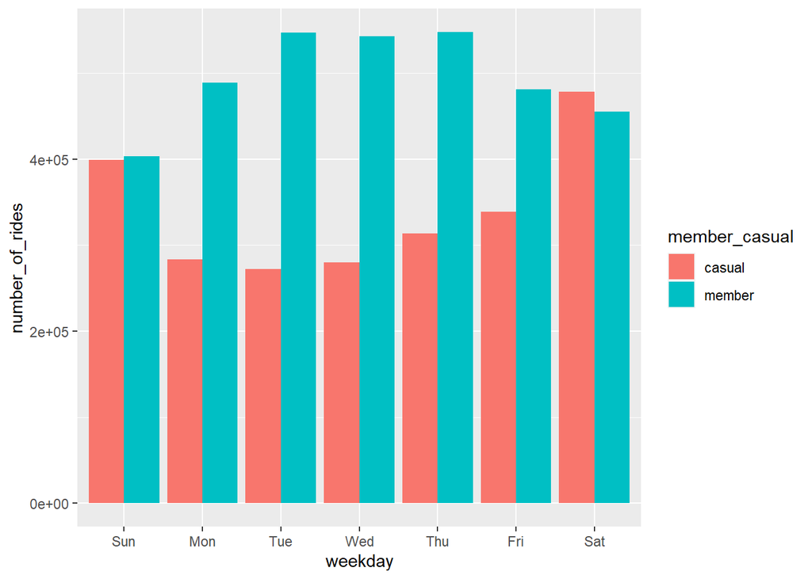

```r
annual_report_v2 %>%
  mutate(weekday = wday(started_at, label=TRUE)) %>%
  group_by(member_casual,weekday) %>%
  summarize(number_of_rides = n(), average_duration = mean(ride_length)) %>%
  arrange(member_casual, weekday) %>%
  ggplot(aes(x=weekday,y=number_of_rides,fill=member_casual))+
  geom_col(position = "dodge")
```

## Next, let’s create a visualization for average duration

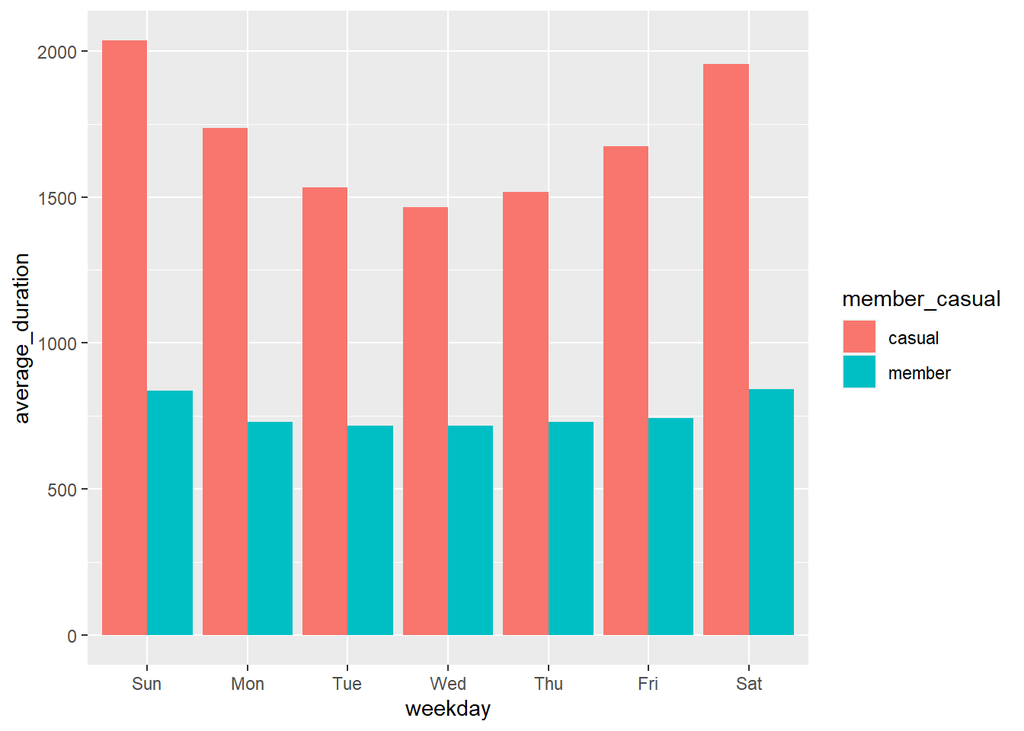

```r
annual_report_v2 %>%
  mutate(weekday = wday(started_at, label=TRUE)) %>%
  group_by(member_casual,weekday) %>%
  summarise(number_of_rides = n(), average_duration = mean(ride_length)) %>%
  arrange(member_casual,weekday) %>%
  ggplot(aes(x=weekday,y=average_duration,fill=member_casual))+
  geom_col(position = "dodge")
```

## Lastly, we will create a csv file that we can vizualize in Excel, Tableau or PowerPoint

We have to set the destination for this file to save.

```r
counts<-aggregate(annual_report_v2$ride_length~annual_report_v2$member_casual +
                    annual_report_v2$day_of_week, FUN = mean)
write.csv(counts, file = "C:/my filess/Data-Analysis/Case_study_1_Cyclistic_Bike-share/average_ride_length.csv")
```